# Machine Learning Algorithms

### 5. SVM (Support Vector Machine)

It is a classification method. In this algorithm, we plot each data item as a point in n-dimensional space (where n is number of features you have) with the value of each feature being the value of a particular coordinate.

For example, if we only had two features like Height and Hair length of an individual, we’d first plot these two variables in two dimensional space where each point has two co-ordinates (these co-ordinates are known as Support Vectors)

General Code

```
#Import Library
require(e1071) #Contains the SVM
Train <- read.csv(file.choose())
Test <- read.csv(file.choose())
# there are various options associated with SVM training; like changing kernel, gamma and C value.

# create model
model <- svm(Target~Predictor1+Predictor2+Predictor3,data=Train,kernel='linear',gamma=0.2,cost=100)

#Predict Output
preds <- predict(model,Test)
table(preds)
```

For example,

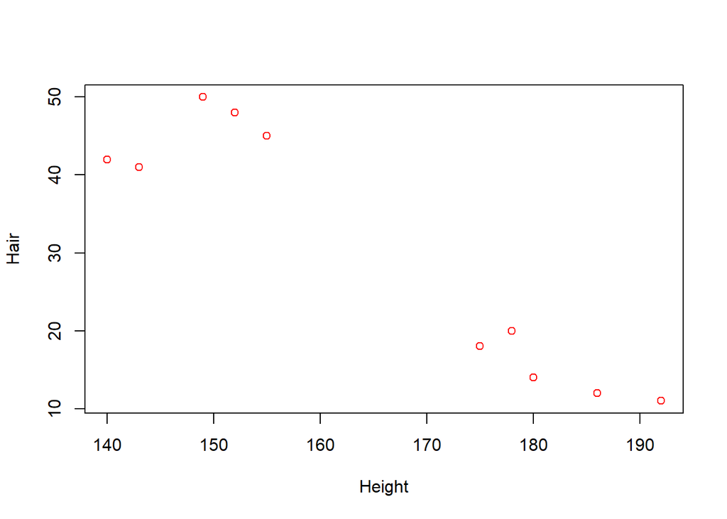

```r
Height = c(140,155,175,180,149,152,178,186,143,192)
Hair = c(42,45,18,14,50,48,20,12,41,11)
train = data.frame(Height,Hair)
plot(Height,Hair,col = "red")
```

Fitting model

```r
library(e1071)
fit <-svm(Height ~ Hair, data = train)
summary(fit)
```

```
##
## Call:
## svm(formula = Height ~ Hair, data = train)
##
##
## Parameters:
##    SVM-Type:  eps-regression
##  SVM-Kernel:  radial
##        cost:  1
##       gamma:  1
##     epsilon:  0.1
##
##
## Number of Support Vectors:  10
```

### 6. Naive Bayes

It is a classification technique based on Bayes’ theorem with an assumption of independence between predictors. In simple terms, a Naive Bayes classifier assumes that the presence of a particular feature in a class is unrelated to the presence of any other feature. For example, a fruit may be considered to be an apple if it is red, round, and about 3 inches in diameter. Even if these features depend on each other or upon the existence of the other features, a naive Bayes classifier would consider all of these properties to independently contribute to the probability that this fruit is an apple.

Naive Bayesian model is easy to build and particularly useful for very large data sets. Along with simplicity, Naive Bayes is known to outperform even highly sophisticated classification methods.

```r
# Import data
data(BreastCancer, package="mlbench")
bc <- BreastCancer[complete.cases(BreastCancer), ]
```

Build the Model in R

```r
library(e1071)

fit <-naiveBayes(Class ~ ., data = bc)
summary(fit)
```

```
##         Length Class  Mode
## apriori  2     table  numeric
## tables  10     -none- list
## levels   2     -none- character
## call     4     -none- call
```

### 7. kNN (k- Nearest Neighbors)

It can be used for both classification and regression problems. However, it is more widely used in classification problems in the industry. K nearest neighbors is a simple algorithm that stores all available cases and classifies new cases by a majority vote of its k neighbors. The case being assigned to the class is most common amongst its K nearest neighbors measured by a distance function.

These distance functions can be Euclidean, Manhattan, Minkowski and Hamming distance. First three functions are used for continuous function and fourth one (Hamming) for categorical variables. If K = 1, then the case is simply assigned to the class of its nearest neighbor. At times, choosing K turns out to be a challenge while performing kNN modeling.

```r
df = iris
head(df)
```

```
##   Sepal.Length Sepal.Width Petal.Length Petal.Width Species
## 1          5.1         3.5          1.4         0.2  setosa
## 2          4.9         3.0          1.4         0.2  setosa
## 3          4.7         3.2          1.3         0.2  setosa
## 4          4.6         3.1          1.5         0.2  setosa
## 5          5.0         3.6          1.4         0.2  setosa
## 6          5.4         3.9          1.7         0.4  setosa
```

```r
str(df)
```

```
## 'data.frame':    150 obs. of  5 variables:
##  $ Sepal.Length: num  5.1 4.9 4.7 4.6 5 5.4 4.6 5 4.4 4.9 ...
##  $ Sepal.Width : num  3.5 3 3.2 3.1 3.6 3.9 3.4 3.4 2.9 3.1 ...
##  $ Petal.Length: num  1.4 1.4 1.3 1.5 1.4 1.7 1.4 1.5 1.4 1.5 ...
##  $ Petal.Width : num  0.2 0.2 0.2 0.2 0.2 0.4 0.3 0.2 0.2 0.1 ...
##  $ Species     : Factor w/ 3 levels "setosa","versicolor",..: 1 1 1 1 1 1 1 1 1 1 ...
```

```r
library(caTools)
set.seed(123)
ran = sample.split(df, SplitRatio = 0.9)
```

Normalization function is created

```r
nor = function(x){
    (x - min(x))/(max(x)-min(x))
}
```

Run nomalization on first 4 columns because they are the predictors

```r
df_norm = as.data.frame(lapply(df[,c(1,2,3,4)],nor))
summary(df_norm)
```

```
##   Sepal.Length     Sepal.Width      Petal.Length     Petal.Width
##  Min.   :0.0000   Min.   :0.0000   Min.   :0.0000   Min.   :0.00000
##  1st Qu.:0.2222   1st Qu.:0.3333   1st Qu.:0.1017   1st Qu.:0.08333
##  Median :0.4167   Median :0.4167   Median :0.5678   Median :0.50000
##  Mean   :0.4287   Mean   :0.4406   Mean   :0.4675   Mean   :0.45806
##  3rd Qu.:0.5833   3rd Qu.:0.5417   3rd Qu.:0.6949   3rd Qu.:0.70833
##  Max.   :1.0000   Max.   :1.0000   Max.   :1.0000   Max.   :1.00000
```

Extract traing and test set

```r
df_train = subset(df_norm, ran == TRUE)
df_test = subset(df_norm, ran == FALSE)

# Extract 5th column of train dataset because it will be used as 'cl' argument in knn function
df_target_category = df[ran,5]

# Extract 5th column if test dataset to measure the accuracy
df_test_category = subset(df$Species,ran == FALSE)
```

Built the Model

```r
library(class)
pr = knn(df_train,df_test,cl = df_target_category,k = 13)
```

Confusion Matrix

```r
tab = table(pr,df_test_category)
tab
```

```
##             df_test_category
## pr           setosa versicolor virginica
##   setosa         10          0         0
##   versicolor      0         10         2
##   virginica       0          0         8
```

This function divides the correct predictions by total number of predictions that tell us how accurate the model is.

```r
accuracy = function(x){
  sum(diag(x)/(sum(rowSums(x))))*100
}
accuracy(tab)
```

```
## [1] 93.33333
```